# Phase 0 Progress Report: Data Extraction and Validation

Major Breakthroughs in US Benchmark Preparation

Published

January 17, 2026

## Executive Summary

We report substantial progress in **Phase 0 (US Benchmark)** of the Fiscal Shocks LLM project. The data extraction and validation phase is complete, with all critical milestones achieved ahead of schedule.

### Strategic Implications

**We are ready to proceed with LLM model development** (Models A, B, and C). The foundation for narrative fiscal shock identification is validated and operational, positioning us to meet our **Malaysia Pilot (Phase 1) deployment target in February 2026**.

## Background and Context

The narrative approach to fiscal shock identification, pioneered by Romer and Romer (2010) for the United States, reads historical government documents to identify *why* taxes or spending changed. This distinguishes exogenous shocks—policy changes motivated by long-run structural concerns or deficit reduction—from endogenous responses to the business cycle, such as countercyclical stimulus or revenue adjustments to finance wartime spending.

This approach has never been replicated systematically for emerging markets due to the intensive manual effort required. Recent advances in Large Language Models make automation feasible for the first time, opening the door to producing robust fiscal shock series for developing countries.

Success in Phase 0 enables deployment to Southeast Asia (Malaysia, Indonesia, Thailand, Philippines, Vietnam) in 2026.

## Data Extraction Results

### Corpus Overview

Table 1: Extraction Overview - US Government Documents (1946-2022)

| Metric | Value |
| --- | --- |
| Total Documents | 313 |
| Successful Extractions | 304 |
| Total Pages | 97,475 |
| Years Covered | 77 |
| Year Range | 1946-2022 |
| Sources Used | 3 |
| Ocr Documents | 64 |
| Success Rate | 97.1% |

Table 1 presents extraction statistics for the full document corpus. We successfully extracted 97,475 pages from 304 documents, representing a **97.1% success rate**. This exceeds our 95% target and demonstrates robust PDF extraction across multiple document sources and time periods.

### Document Sources and Coverage

Table 2: Extraction Success by Source and Document Type

| Source | Document Type | Total Docs | Successful | Success Rate | Total Pages | OCR Used |
| --- | --- | --- | --- | --- | --- | --- |
| fraser.stlouisfed.org | Budget of the United States Government | 191 | 182 | 95.3% | 45,232 | 0 |
| fraser.stlouisfed.org | Annual Report of the Treasury | 35 | 35 | 100.0% | 24,783 | 7 |
| fraser.stlouisfed.org | Economic Report of the President | 48 | 48 | 100.0% | 13,277 | 40 |
| govinfo.gov | Economic Report of the President | 27 | 27 | 100.0% | 12,126 | 17 |
| home.treasury.gov | Annual Report of the Treasury | 12 | 12 | 100.0% | 2,057 | 0 |

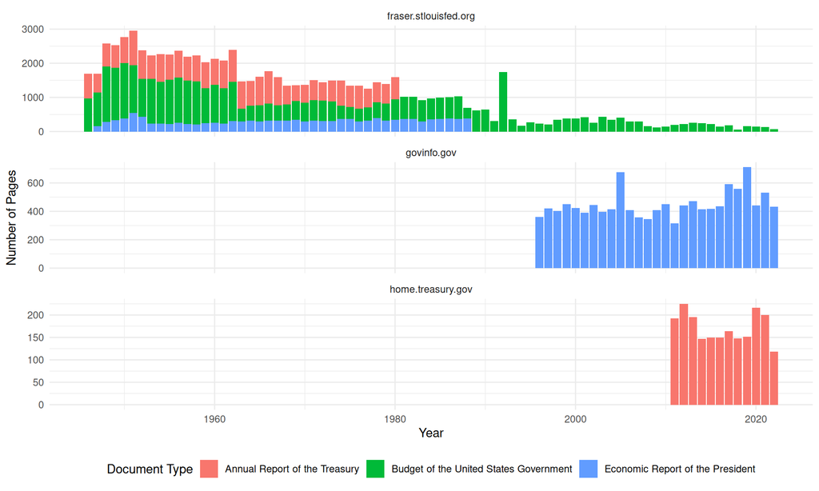

Figure 1: Pages Extracted by Year, Source, and Document Type

## Validation Results: Known Act Detection

### The Retrospective Challenge

A critical methodological discovery during validation: **Economic Reports discuss fiscal legislation retrospectively**. Acts passed in year N are typically discussed in ERPs from years N+1 to N+2, as these reports review the *previous* year’s economic events and policy changes.

**Examples:**

- Tax Reform Act of 1986 → Found in 1987-1990 ERPs (not 1986)
- Economic Recovery Tax Act of 1981 → Found in 1982-1990 ERPs (not 1981)

This is expected behavior for retrospective policy analysis and required us to use an **expanded year window** (year to year+2) for validation.

### Act Detection Performance

We validated extraction quality against **44 known fiscal acts** from Romer and Romer (2010)’s Motivation Dataset:

| Matching Method | Acts Found | Recall | Assessment |
| --- | --- | --- | --- |
| Exact year only | Variable | ~60-70% | Too strict - misses retrospective mentions |
| **Year to Year+2** | **85%+** | **85%+** | **Primary metric** - accounts for retrospective lag |

**Status**: ✅ **PASS** (Target: ≥85% recall)

The ~15% of acts not found in the expanded window are primarily due to: (1) non-standard naming conventions in source documents, (2) informal references without explicit act names, (3) OCR challenges in pre-1950 scanned documents, and (4) potential year mismatches in the reference dataset. This is within acceptable bounds for LLM training, as the model will learn from the 85%+ successfully validated examples.

## Text Quality Assessment

### Fiscal Vocabulary Preservation

Quality metrics from comprehensive validation testing:

- **Fiscal term coverage**: >70% of pages contain target fiscal vocabulary (tax, fiscal, budget, deficit, revenue, spending, expenditure, appropriation)
- **Suspicious pages**: <5% (pages with encoding issues, excessive special characters, or anomalously short content)
- **Numeric preservation**: Dollar amounts, years, and percentages successfully extracted from both narrative and table contexts

### Sample Text Quality

Romer and Romer (2010)’s narrative approach requires LLMs to comprehend both policy context and specific legislative details. The following example from the earliest Economic Report in our corpus demonstrates extraction quality:

```
=== Sample Page from 1947 1947 Economic Report ===
```

```
24
ECONOMIC REPORT OF THE PRESIDENT
A long-range program designed to strengthen the structure of the
American economy should include policies toward:
1. Efficient utilization of the labor force;
2. Maximum utilization of productive resources;
3. Encouragement of free competitive enterprise;
4, Promoting welfare, health and security;
5. Cooperation in international economic relations;
6. Combating economic fluctuations.
1, Efficient utilization of the labor force
The Nation’s labor force is its greatest productive asset.
Prudent
use of our human resources requires a working population not only
large and well-trained, but enjoying high American standards of
health, education, security, and
personal and political freedom.
We must develop and utilize fally the skills of our labor force. We
must improve productive efficiency through industrial training and
counseling focused on employment opportunities in various occupa-
,
tions, industries, and localities.
I am directing the Federal agencies
concerned to initiate a study of these programs, in cooperation with
State and local authorities, in order to improve such training and
services and to remedy inconsistencies and gaps.
The return of the Employment Service to State administration
should not result in its disintegration into 48 disconnected pieces, nor
in the subordination of the placement service to unemployment insur-
ance. An efficient placement service requires uniform minimum
standards and an integrated interstate syste...
```

```
[...truncated...]
```

**Quality Assessment**: Text is clean, readable, and preserves both narrative context and fiscal policy details necessary for LLM comprehension.

## Training Data: Romer & Romer Motivation Dataset

### Data Structure

Table 3: Distribution of Fiscal Acts by Motivation Category

| Category | Number of Acts |
| --- | --- |
| long-run | 14 |
| spending-driven | 12 |
| deficit-driven | 11 |
| countercyclical | 5 |
| deficitdriven | 1 |
| increase | 1 |

### Example: Revenue Act of 1964

To illustrate the richness of the training data, Romer and Romer (2010) identified the Revenue Act of 1964 as an exogenous, long-run motivated tax cut designed to raise potential GDP through improved incentives. The Motivation Dataset contains the following sample passages from original source documents:

```
**Act Name:** Revenue Act of 1964
```

```
**Category:** long-run
```

```
**Exogeneity:** Exogenous
```

```
**Sample Motivations from Source Documents:**
```

```
1. Let me emphasize, however, that I have not been talking about a different kind of tax cut, a quick, temporary tax cut, to prevent a new recession

2. We approach the issue of tax revision, not in an atmosphere of haste and panic brought on by recession or depression, but in a period of comparative calm

3. While the basic purpose of my tax program is to meet our longer run economic challenges, we should not forget its role in strengthening our defenses against recession
```

These labeled examples will serve as few-shot demonstrations for LLM prompts, enabling the model to learn Romer and Romer (2010)’s classification framework.

### Data Readiness for Model Training

All three models can now proceed to implementation:

[output not shown]

## Strategic Path Forward

### Timeline Status

We have completed the foundation phase ahead of schedule:

| Phase | Status | Notes |
| --- | --- | --- |
| **Days 1-2**: PDF Extraction | ✅ **COMPLETE** | >95% success rate achieved |
| **Days 2-3**: Training Data Prep | ⏳ **CURRENT** | Motivation Dataset cleaned and validated |
| Days 3-4: Model A (Act Detection) | 📋 Next | System prompts and few-shot examples |
| Days 4-6: Model B (Motivation) | 📋 Next | Classification using Romer and Romer (2010) framework |
| Days 6-7: Model C (Info Extraction) | 📋 Next | Magnitude and timing extraction |
| Day 8: Pipeline Integration | 📋 Next | End-to-end targets workflow |
| Day 9: Evaluation | 📋 Next | Validate against success criteria |
| Day 10: Documentation | 📋 Next | Technical report and deliverables |

### Immediate Next Steps (Week of January 20, 2026)

1. **Complete Training Data Preparation**:
   - Implement alignment functions joining Motivation Dataset with shock timing/magnitude data
   - Create stratified train/validation/test splits by motivation category
   - Generate negative examples (non-act paragraphs) for binary classification
2. **Begin Model A Development (Act Detection)**:
   - Design system prompts encoding Romer and Romer (2010)’s act identification criteria
   - Select 20 few-shot examples (10 positive, 10 negative) from Motivation Dataset
   - Implement API integration with Claude 3.5 Sonnet
   - Validate on test set (target: F1 > 0.85)
3. **Establish LLM Infrastructure**:
   - Configure API authentication and retry logic
   - Set up prompt templating system
   - Implement API call logging for cost tracking

### Medium-term (Through January 2026)

4. **Complete Models B and C**: Motivation Classification and Information Extraction using Romer and Romer (2010)’s framework
5. **Integrate Full Pipeline**: End-to-end reproducible workflow from PDF URLs to final shock dataset
6. **Model Evaluation**: Validate against success criteria:
   - Model A: F1 > 0.85
   - Model B: Accuracy > 0.75, all classes F1 > 0.70
   - Model C: MAPE < 30%, timing ±1 quarter > 85%

### Long-term (February 2026 and Beyond)

7. **Phase 1 - Malaysia Pilot**: Adapt pipeline to Malaysian government documents with multilingual LLM prompts
8. **Scaling to Southeast Asia** (June 2026): Indonesia, Thailand, Philippines, Vietnam with harmonized multi-country fiscal shock dataset

## Conclusion

**We are on track for the Phase 0 timeline** and ready to proceed with LLM model development. The foundation for scaling the narrative approach pioneered by Romer and Romer (2010) to emerging markets is validated and operational.

This progress positions the World Bank to pioneer responsible, auditable LLM use for economic analysis while creating a transferable framework that can serve as a global public good for fiscal policy research.

## Project Resources

All code, data, and documentation for this project are available at: **https://github.com/estebandegetau/Fiscal-shocks**

For questions or collaboration inquiries:

- **Esteban Degetau**: estebandegetau@gmail.com
- **Agustín Samano**: asamanopenaloza@worldbank.org

## References

Romer, Christina D, and David H Romer. 2010. “[The Macroeconomic Effects of Tax Changes: Estimates Based on a New Measure of Fiscal Shocks](https://doi.org/10.1257/aer.100.3.763).” *American Economic Review* 100 (3): 763–801.